# DATA 510

# Cleaning, Organizing, & Visualizing Data

## Brandan Scully, PE, PhD

# Front Matters

## Introductions

Give a quick bio, your experience working with data, what you hope to get out of this class

## [About Me](https://www.linkedin.com/in/brandanscully/)

## Important Dates

September 21 - Remote Class

November 9,16 - I'm unavailable. How do we want to proceed?

## Syllabus - Assignment Weights

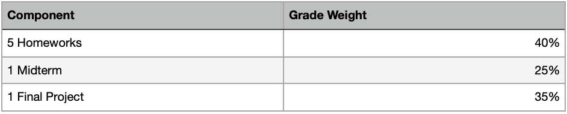

# Course Goals

To **understand the difference between the different types of data** (structured, semi-structured, unstructured, and metadata) **and how this impacts underlying storage mechanisms.**

Be able to **select** and **implement** the **optimal data management system and associated workflow** as a function of the data’s **Volume, Velocity, Variety,** and **Veracity**.

To **construct** and **perform queries** to **select data** for **assembly into an analysis workflow** for data science.

To understand the need for and to use an available tool to carry out **data cleaning** and other **data pre-processing activities in preparing data resources** integrated from various sources.

To understand **common patterns of data flow through data science analysis workflows**, such as big data processing patterns using a parallel processing paradigm such as map-reduce.

To understand and compare **common data visualization methods** for data science.

# Software Stuff

Python! I like [Anacondas](https://www.anaconda.com/products/distribution)

[Git](https://git-scm.com/)

# What is "Data Science"

- [Data Scientist: The sexiest Job of the 21st Century](https://hbr.org/2012/10/data-scientist-the-sexiest-job-of-the-21st-century)
- [Data Scientits use **data** and **science** to **generate valuable insights**](https://www.techtarget.com/searchenterpriseai/definition/data-science)

[figure not shown]

Ref [right image](https://towardsdatascience.com/7-resources-for-those-wanting-to-learn-data-science-a89e25d1b55e)

# The **4 V's** of Big Data

**Volume**: The size of the dataset.

- At this point > terabyte, petabyte.

**Velocity**: The speed at which data are generated.

- Typically requires distinct processing approach.

**Variety**: Data come from multiple sources.

- Google ranks *all* pages on the internet.

**Veracity**: The quality of data.

- High veracity: valuable for analysis, e.g. well controlled experimental observations
- Low veracity: lots of low-value "noise"

Ref: https://www.bigdataframework.org/the-four-vs-of-big-data/

# Data Science Workflow

- ["A workflow describes the way people perform tasks to get the work done"](https://neptune.ai/blog/best-practices-for-data-science-project-workflows-and-file-organizations)
- Define the problem
- Collect data
- Data Exploration
- Data Modeling
- **Communicating Results**

[figure not shown]

# Data Science?

"Apply some machine learning to our data using cloud computing."

# Data Science Problem Types

**Descriptive** - [Summarize a dataset](https://towardsdatascience.com/descriptive-statistics-f2beeaf7a8df)

**[Exploratory](https://www.analyticsvidhya.com/blog/2016/01/guide-data-exploratio/)** - Find patterns, trends, or relationships in a dataset.

- "Hypothesis generation" e.g. [Spurious Correlations](https://www.tylervigen.com/spurious-correlations)!

**Inferential** - Does your data represent a larger population?

- Understanding [bias](https://www.metabase.com/blog/6-most-common-type-of-data-bias-in-data-analysis) and causes.

Ref: [The Art of Data Science](https://bookdown.org/rdpeng/artofdatascience/types-of-questions.html)

# Data Science Problem Types

**Predictive** - Given a set of input variables, generate a "better than random" guess of the output value. e.g. [Regression Analysis](https://corporatefinanceinstitute.com/resources/knowledge/finance/regression-analysis)

- **[Causal](https://medium.com/causal-data-science/causal-data-science-721ed63a4027)** - Finding the input variable that changes the output value.

**Mechanistic** - Finding the underlying mechanism that drives the output value given certain input bariables.

- Singapore's [Circle Line Train](https://github.com/datagovsg-blog/circle-line-analytics)
- [*Medium*: How the Circle Line rogue train was caught with data](https://medium.com/datagovsg-blog/how-we-caught-the-circle-line-rogue-train-with-data-79405c86ab6a)
- The first link goes to the git repo. The second link goes to medium, search "circle line train" on the right. It's a great example of both analysis and how to communicate complex data science problems.

[Use Cases](https://www.futurebusinesstech.com/blog/top-20-data-science-use-cases)

Ref: [The Art of Data Science](https://bookdown.org/rdpeng/artofdatascience/types-of-questions.html)

# Data Types

**Structured Data**: Data that fit a predefined model or format for straightforward analysis.

- Requires or assumes a data model
- See: [Tidy Data (for *R*)](https://cran.r-project.org/web/packages/tidyr/vignettes/tidy-data.html)

**Semi-Structured Data**: Data that do not fit a predefined model, but can be parsed to fit a data model or format.

- Think [JSON](https://www.json.org/json-en.html), [BSON](https://www.mongodb.com/basics/bson), [XML](https://www.w3.org/standards/xml/core), [HTML](https://html.spec.whatwg.org/), etc.
- See: [Data Wrangling](https://en.wikipedia.org/wiki/Data_wrangling#cite_note-3)

Ref: https://www.bigdataframework.org/data-types-structured-vs-unstructured-data/

# Data Types

**Unstructured Data**: Data that do not fit a predefined model.

- Think: [emails, text files, audio/video, social media, mobile data, books, etc.](https://www.intellspot.com/unstructured-data-examples/)

**Metadata**: Data about data.

- Usually some of the most important data you’ll work with!

Ref: https://www.bigdataframework.org/data-types-structured-vs-unstructured-data/

# Data Storage

The *type* and *end use* of data dictate how it is stored and processed.

**Structured Query Language (SQL)** – Best for storing structured and semi-structured data.

**Non-Structured Query Language (NoSQL)** – Best for storing unstructured data.

[figure not shown]

Ref: https://www.bigdataframework.org/data-types-structured-vs-unstructured-data/

https://mrsaeeddev.medium.com/learn-how-to-store-data-for-your-data-science-problems-even-if-you-dont-want-to-27e02dd9f781

# A Dated Example

If I know your name and the area code your phone is linked to… look up alphabetically by last name.

[figure not shown]

Suppose you want to know Jenny’s last name, but you don’t want to call 867-5309?

## Moving Data: ETL

The process of accessing, shaping, and inserting data within a data science workflow is referred to **ETL** or: **Extract**: Obtaining data from (typically heterogeneous) source(s) in preparation for use in a data science workflow.

- [API Call](https://rapidapi.com/blog/most-popular-api/)
- [Web Scraping](https://realpython.com/python-web-scraping-practical-introduction/)
- [Historical Document Analysis](https://programminghistorian.org/en/)

**Transform**: Shaping data into a useable (temporary) format (schema).

- Missing Values/Sentinel Values
- *[Feature Engineering](https://www.analyticsvidhya.com/blog/2021/03/step-by-step-process-of-feature-engineering-for-machine-learning-algorithms-in-data-science/)*

**Load**: Writing processed data to a target database.

[figure not shown]

**ETL Pipeline**: the workflow (programmatic) for doing ETL.

Ref: https://www.databricks.com/glossary/extract-transform-load

# Data Access

The *type* and *end use* of data dictate how it is accessed (efficiently)

**Search Engine** – Good for text queries.

- Google Cloud Search, Elastic Search, Apache Solr

**Document Store** – Flexible schema.

- Amazon DynamoDB, Mongo DB, Apache Couch DB

**Columnar Store** – Good for single column queries and value aggregations.

- Amazon Redshift, Google BigQuery, Apache HBase

Ref: https://www.toptal.com/data-science/data-engineering-guide-to-storages

# [Exploratory Data Analysis](https://tinyurl.com/TukeyCofC)

[figure not shown]

Ref: https://mbounthavong.com/blog/tag/John+Tukey

**Exploratory Data Analysis: Common Visualizations**

[figure not shown]

Ref [EDA in Python](https://blog.cambridgespark.com/exploratory-data-analysis-in-python-ab7580d5726c)

**Data Modeling vs. Data Structure Modeling**

Data Modeling: [An Introduction to Statistical Learning](https://www.statlearning.com/)

Data Structure Modeling:

[figure not shown]

Ref:[Data Models](https://www.javatpoint.com/data-models)

# Data Visualization

"Simple design, intense content" - Edward Tufte

[The Visual Display of Quantitative Information](https://www.edwardtufte.com/tufte/books_vdqi)

Convey the content of the data in a manner sufficient to inspire action. -me

**Carte figurative des pertes successives en hommes de l’Armée Française dans la campagne de Russie 1812-1813.**

Charles Joseph Minard, 1869

This iconic image was created to “[force a revisionist public to remember](https://edspace.american.edu/visualwar/minard/)” the costs of war.

[figure not shown]

**On the Mode of Communication of Cholera**

John Snow, 1854

This iconic image assisted the identification of a communal water pump contaminated with Cholera.

[figure not shown]

**[Notes on matters affecting the health, efficiency, and hospital administration of the British Army : founded chiefly on the experience of the late war / by Florence Nightingale ; presented by request to the Secretary of State for War](https://wellcomecollection.org/works/jxwtskzc)**

Florence Nightingale, 1858

The “[Rose Diagram](https://www.maharam.com/stories/sherlock_florence-nightingales-rose-diagram)” identified epidemic diseases as the prevailing cause of death during the Crimean War and persuaded the use of sanitary controls to address them.

[figure not shown]

**[Out of Sight, Out of Mind: A Visualization of Drone Strikes in Pakistan Since 2004.](https://drones.pitchinteractive.com/)** Pitch Interactive, 2015

This modern interactive visualization galvanized public opinion about the expanding use of drone strikes in Pakistan under President Obama.

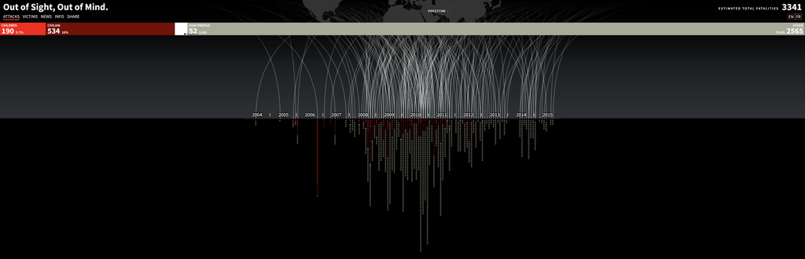

**[Computing Optimal Road Trips on a Limited Budget](https://randalolson.com/2016/06/05/computing-optimal-road-trips-on-a-limited-budget/?xid=PS_sunset)**

This blog post comparatively explained the use of a genetic algorithm and multi-objective pareto optimization to find the shortest route to visit 48 state capitols in 8 ½ days using the Google Maps API. These are popular techniques for optimizing business problems.

[figure not shown]